# HMW7_PRINCESS

# stating the Null hypothesis which is H0 below

# H0 -There is NO relationship between life expectancy and gdpPercap.

#stating the alaternate hypothesis # HA There is a relationship between life expectancy and gdpPercap.

```r
x <- c(68.750,69.960, 71.300, 72.130, 72.880, 74.210, 75.760, 76.860, 77.950, 78.610,79.770,80.653)
x
```

```
##  [1] 68.750 69.960 71.300 72.130 72.880 74.210 75.760 76.860 77.950 78.610
## [11] 79.770 80.653
```

```r
y <- c(11367.16, 12489.95, 13462.49, 16076.59, 18970.57, 22090.88, 22898.79, 26626.52, 26342.88, 28954.93, 33328.97, 36319.24)
y
```

```
##  [1] 11367.16 12489.95 13462.49 16076.59 18970.57 22090.88 22898.79 26626.52
##  [9] 26342.88 28954.93 33328.97 36319.24
```

#To check the correlation test with my sample data i would run the argument below

```r
corr.1 <- round(cor(x,y),2)
corr.1
```

```
## [1] 0.99
```

```r
view(corr.1)
cor.test(x,y)
```

```
##
##  Pearson's product-moment correlation
##
## data:  x and y
## t = 18.712, df = 10, p-value = 4.109e-09
## alternative hypothesis: true correlation is not equal to 0
## 95 percent confidence interval:
##  0.9493136 0.9961957
## sample estimates:
##       cor
## 0.9860194
```

```r
#cor value is 0.99
```

##Answer #gapminder is a dataset that has six variables(coloumns) ,“country”, “continent”, “year”,“life expectancy”, “population”,and “gdpPercapita” and 1704 observations (rows).This Data is available for one hundred and forty two (142) countries for every five years from 1952 to 2007 #descriptive statics of the gapminder dataset

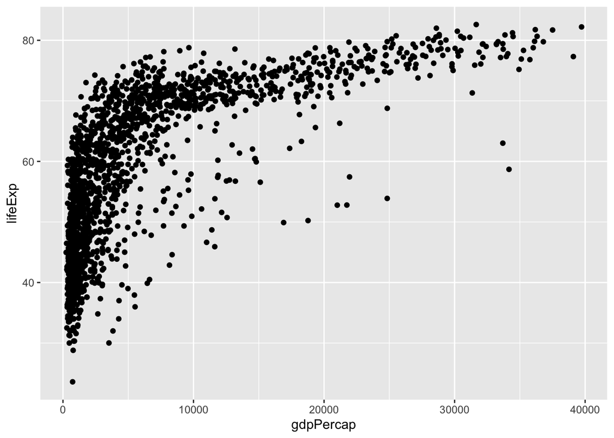

```r
gapminder %>%
  filter(gdpPercap < 40000) %>%
  ggplot(aes(x=gdpPercap, y=lifeExp)) +
  geom_point()
```

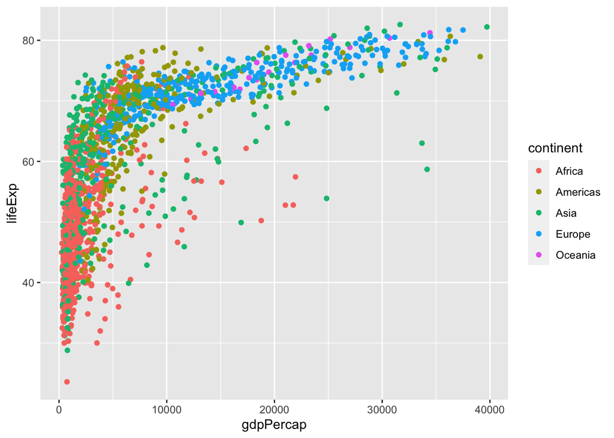

```r
gapminder %>%
  filter(gdpPercap < 40000) %>%
  ggplot(aes(x=gdpPercap, y=lifeExp, col = continent)) +
  geom_point()
```

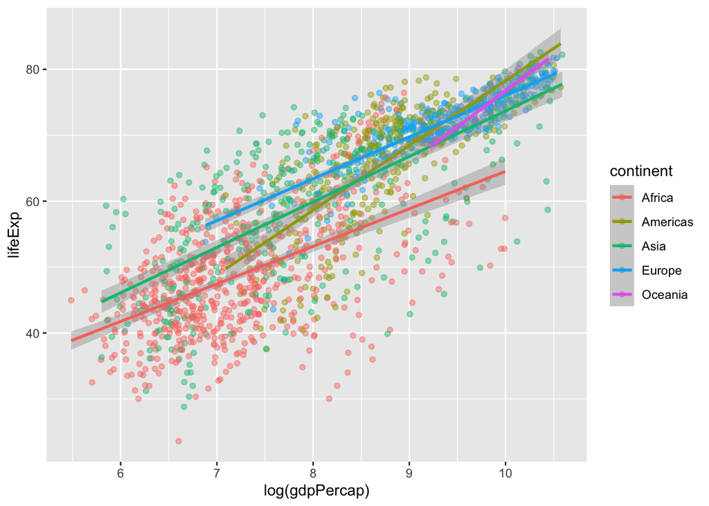

```r
gapminder %>%
  filter(gdpPercap < 40000) %>%
  ggplot(aes(x=log(gdpPercap), y=lifeExp, col = continent)) +
  geom_point(alpha = .45) +
  geom_smooth(method = lm)
```